# Risk Factor Analysis

## Outcome Variable

**Outcome Variable:** haz

## Predictor Variables

**Intervention Variable:** nchldlt5

**Adjustment Set:**

- arm
- W_mage
- meducyrs
- feducyrs
- hhwealth_quart
- hfoodsec
- W_mhtcm
- W_mwtkg
- W_mbmi
- W_nrooms
- W_parity
- impfloor
- impsan
- safeh20
- delta_W_mage
- delta_meducyrs
- delta_feducyrs
- delta_hhwealth_quart
- delta_hfoodsec
- delta_W_mhtcm
- delta_W_mwtkg
- delta_W_mbmi
- delta_W_nrooms
- delta_W_parity
- delta_impfloor
- delta_impsan
- delta_safeh20

## Stratifying Variables

The analysis was stratified on these variable(s):

- agecat
- studyid
- country

## Data Summary

| agecat | studyid | country | nchldlt5 | n_cell | n | outcome_variable |
| --- | --- | --- | --- | --- | --- | --- |
| Birth | IRC | INDIA | 1 | 84 | 388 | haz |
| Birth | IRC | INDIA | 2+ | 304 | 388 | haz |
| Birth | JiVitA-3 | BANGLADESH | 1 | 13986 | 22431 | haz |
| Birth | JiVitA-3 | BANGLADESH | 2+ | 8445 | 22431 | haz |
| Birth | NIH-Crypto | BANGLADESH | 1 | 522 | 732 | haz |
| Birth | NIH-Crypto | BANGLADESH | 2+ | 210 | 732 | haz |
| Birth | PROVIDE | BANGLADESH | 1 | 391 | 539 | haz |
| Birth | PROVIDE | BANGLADESH | 2+ | 148 | 539 | haz |
| 6 months | IRC | INDIA | 1 | 89 | 407 | haz |
| 6 months | IRC | INDIA | 2+ | 318 | 407 | haz |
| 6 months | JiVitA-3 | BANGLADESH | 1 | 10887 | 16800 | haz |
| 6 months | JiVitA-3 | BANGLADESH | 2+ | 5913 | 16800 | haz |
| 6 months | LCNI-5 | MALAWI | 1 | 390 | 811 | haz |
| 6 months | LCNI-5 | MALAWI | 2+ | 421 | 811 | haz |
| 6 months | NIH-Crypto | BANGLADESH | 1 | 507 | 715 | haz |
| 6 months | NIH-Crypto | BANGLADESH | 2+ | 208 | 715 | haz |
| 6 months | PROVIDE | BANGLADESH | 1 | 438 | 604 | haz |
| 6 months | PROVIDE | BANGLADESH | 2+ | 166 | 604 | haz |
| 6 months | TanzaniaChild2 | TANZANIA, UNITED REPUBLIC OF | 1 | 1391 | 2020 | haz |
| 6 months | TanzaniaChild2 | TANZANIA, UNITED REPUBLIC OF | 2+ | 629 | 2020 | haz |
| 24 months | IRC | INDIA | 1 | 89 | 409 | haz |
| 24 months | IRC | INDIA | 2+ | 320 | 409 | haz |
| 24 months | JiVitA-3 | BANGLADESH | 1 | 5454 | 8622 | haz |
| 24 months | JiVitA-3 | BANGLADESH | 2+ | 3168 | 8622 | haz |
| 24 months | LCNI-5 | MALAWI | 1 | 283 | 571 | haz |
| 24 months | LCNI-5 | MALAWI | 2+ | 288 | 571 | haz |
| 24 months | NIH-Crypto | BANGLADESH | 1 | 357 | 514 | haz |
| 24 months | NIH-Crypto | BANGLADESH | 2+ | 157 | 514 | haz |
| 24 months | PROVIDE | BANGLADESH | 1 | 424 | 578 | haz |
| 24 months | PROVIDE | BANGLADESH | 2+ | 154 | 578 | haz |
| 24 months | TanzaniaChild2 | TANZANIA, UNITED REPUBLIC OF | 1 | 5 | 6 | haz |
| 24 months | TanzaniaChild2 | TANZANIA, UNITED REPUBLIC OF | 2+ | 1 | 6 | haz |

The following strata were considered:

- agecat: 24 months, studyid: IRC, country: INDIA
- agecat: 24 months, studyid: JiVitA-3, country: BANGLADESH
- agecat: 24 months, studyid: LCNI-5, country: MALAWI
- agecat: 24 months, studyid: NIH-Crypto, country: BANGLADESH
- agecat: 24 months, studyid: PROVIDE, country: BANGLADESH
- agecat: 24 months, studyid: TanzaniaChild2, country: TANZANIA, UNITED REPUBLIC OF
- agecat: 6 months, studyid: IRC, country: INDIA
- agecat: 6 months, studyid: JiVitA-3, country: BANGLADESH
- agecat: 6 months, studyid: LCNI-5, country: MALAWI
- agecat: 6 months, studyid: NIH-Crypto, country: BANGLADESH
- agecat: 6 months, studyid: PROVIDE, country: BANGLADESH
- agecat: 6 months, studyid: TanzaniaChild2, country: TANZANIA, UNITED REPUBLIC OF
- agecat: Birth, studyid: IRC, country: INDIA
- agecat: Birth, studyid: JiVitA-3, country: BANGLADESH
- agecat: Birth, studyid: NIH-Crypto, country: BANGLADESH
- agecat: Birth, studyid: PROVIDE, country: BANGLADESH

### Dropped Strata

Some strata were dropped due to rare outcomes:

- agecat: 24 months, studyid: TanzaniaChild2, country: TANZANIA, UNITED REPUBLIC OF

## Methods Detail

We’re interested in the causal parameters $E[Y_a]$ for all values of $a \in \mathcal{A}$. These parameters represent the mean outcome if, possibly contrary to fact, we intervened to set all units to have $A=a$. Under the randomization and positivity assumptions, these are identified by the statistical parameters $\psi_a=E_W[E_{Y|A,W}(Y|A=a,W)]$. In addition, we’re interested in the mean of $Y$, $E[Y]$ under no intervention (the observed mean). We will estimate these parameters by using SuperLearner to fit the relevant likelihood factors – $E_{Y|A,W}(Y|A=a,W)$ and $p(A=a|W)$, and then updating our likelihood fit using a joint TMLE.

For unadjusted analyses ($W=\{\}$), initial likelihoods were estimated using Lrnr_glm to estimate the simple $E(Y|A)$ and Lrnr_mean to estimate $p(A)$. For adjusted analyses, a small library containing Lrnr_glmnet, Lrnr_xgboost, and Lrnr_mean was used.

Having estimated these parameters, we will then use the delta method to estimate relative risks and attributable risks relative to a prespecified baseline level of $A$.

# Results Detail

## Results Plots

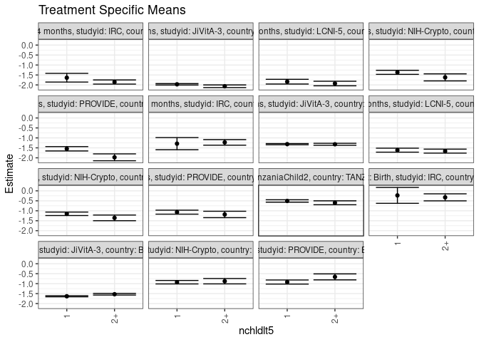

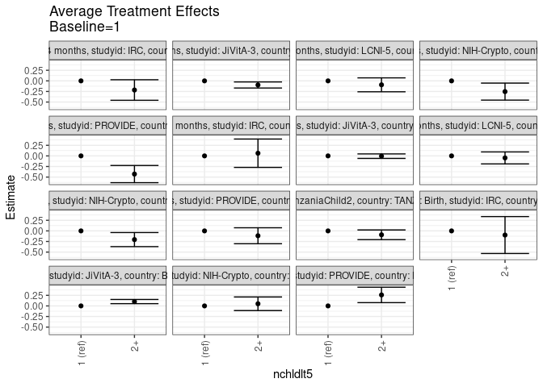

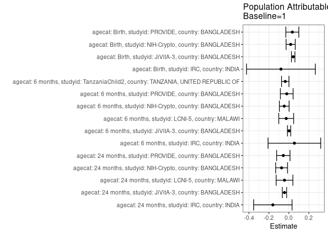

## Results Table

### Parameter: TSM

| agecat | studyid | country | intervention_level | baseline_level | estimate | ci_lower | ci_upper |
| --- | --- | --- | --- | --- | --- | --- | --- |
| Birth | IRC | INDIA | 1 | NA | -0.2284500 | -0.6261371 | 0.1692372 |
| Birth | IRC | INDIA | 2+ | NA | -0.3263822 | -0.5028470 | -0.1499175 |
| Birth | JiVitA-3 | BANGLADESH | 1 | NA | -1.6329493 | -1.6603800 | -1.6055185 |
| Birth | JiVitA-3 | BANGLADESH | 2+ | NA | -1.5304065 | -1.5726878 | -1.4881251 |
| Birth | NIH-Crypto | BANGLADESH | 1 | NA | -0.9271318 | -1.0144334 | -0.8398301 |
| Birth | NIH-Crypto | BANGLADESH | 2+ | NA | -0.8765996 | -1.0112121 | -0.7419870 |
| Birth | PROVIDE | BANGLADESH | 1 | NA | -0.9194922 | -1.0220958 | -0.8168885 |
| Birth | PROVIDE | BANGLADESH | 2+ | NA | -0.6602047 | -0.8106505 | -0.5097589 |
| 6 months | IRC | INDIA | 1 | NA | -1.2894681 | -1.5943913 | -0.9845448 |
| 6 months | IRC | INDIA | 2+ | NA | -1.2263285 | -1.3661946 | -1.0864625 |
| 6 months | JiVitA-3 | BANGLADESH | 1 | NA | -1.3146486 | -1.3433786 | -1.2859187 |
| 6 months | JiVitA-3 | BANGLADESH | 2+ | NA | -1.3208428 | -1.3708687 | -1.2708169 |
| 6 months | LCNI-5 | MALAWI | 1 | NA | -1.6162384 | -1.7163486 | -1.5161283 |
| 6 months | LCNI-5 | MALAWI | 2+ | NA | -1.6639811 | -1.7642193 | -1.5637430 |
| 6 months | NIH-Crypto | BANGLADESH | 1 | NA | -1.1523464 | -1.2393235 | -1.0653693 |
| 6 months | NIH-Crypto | BANGLADESH | 2+ | NA | -1.3576541 | -1.4995901 | -1.2157181 |
| 6 months | PROVIDE | BANGLADESH | 1 | NA | -1.0701443 | -1.1698426 | -0.9704459 |
| 6 months | PROVIDE | BANGLADESH | 2+ | NA | -1.1847853 | -1.3448852 | -1.0246855 |
| 6 months | TanzaniaChild2 | TANZANIA, UNITED REPUBLIC OF | 1 | NA | -0.5075367 | -0.5676496 | -0.4474238 |
| 6 months | TanzaniaChild2 | TANZANIA, UNITED REPUBLIC OF | 2+ | NA | -0.5993967 | -0.6976186 | -0.5011747 |
| 24 months | IRC | INDIA | 1 | NA | -1.6381955 | -1.8566362 | -1.4197549 |
| 24 months | IRC | INDIA | 2+ | NA | -1.8538507 | -1.9580686 | -1.7496327 |
| 24 months | JiVitA-3 | BANGLADESH | 1 | NA | -1.9693133 | -2.0047904 | -1.9338362 |
| 24 months | JiVitA-3 | BANGLADESH | 2+ | NA | -2.0662397 | -2.1319086 | -2.0005709 |
| 24 months | LCNI-5 | MALAWI | 1 | NA | -1.8366451 | -1.9549617 | -1.7183284 |
| 24 months | LCNI-5 | MALAWI | 2+ | NA | -1.9295004 | -2.0435067 | -1.8154941 |
| 24 months | NIH-Crypto | BANGLADESH | 1 | NA | -1.3679947 | -1.4698893 | -1.2661000 |
| 24 months | NIH-Crypto | BANGLADESH | 2+ | NA | -1.6213312 | -1.7977957 | -1.4448668 |
| 24 months | PROVIDE | BANGLADESH | 1 | NA | -1.5467043 | -1.6558610 | -1.4375476 |
| 24 months | PROVIDE | BANGLADESH | 2+ | NA | -1.9758830 | -2.1488915 | -1.8028746 |

### Parameter: E(Y)

| agecat | studyid | country | intervention_level | baseline_level | estimate | ci_lower | ci_upper |
| --- | --- | --- | --- | --- | --- | --- | --- |
| Birth | IRC | INDIA | NA | NA | -0.3080412 | -0.4687931 | -0.1472894 |
| Birth | JiVitA-3 | BANGLADESH | NA | NA | -1.5897031 | -1.6089786 | -1.5704276 |
| Birth | NIH-Crypto | BANGLADESH | NA | NA | -0.9094945 | -0.9809370 | -0.8380521 |
| Birth | PROVIDE | BANGLADESH | NA | NA | -0.8851020 | -0.9601332 | -0.8100709 |
| 6 months | IRC | INDIA | NA | NA | -1.2344062 | -1.3658524 | -1.1029600 |
| 6 months | JiVitA-3 | BANGLADESH | NA | NA | -1.3131375 | -1.3362767 | -1.2899983 |
| 6 months | LCNI-5 | MALAWI | NA | NA | -1.6431566 | -1.7128296 | -1.5734836 |
| 6 months | NIH-Crypto | BANGLADESH | NA | NA | -1.1986783 | -1.2700937 | -1.1272630 |
| 6 months | PROVIDE | BANGLADESH | NA | NA | -1.0916915 | -1.1661176 | -1.0172654 |
| 6 months | TanzaniaChild2 | TANZANIA, UNITED REPUBLIC OF | NA | NA | -0.5442232 | -0.5932373 | -0.4952090 |
| 24 months | IRC | INDIA | NA | NA | -1.7987775 | -1.8923914 | -1.7051636 |
| 24 months | JiVitA-3 | BANGLADESH | NA | NA | -2.0134284 | -2.0411019 | -1.9857549 |
| 24 months | LCNI-5 | MALAWI | NA | NA | -1.8806830 | -1.9625334 | -1.7988326 |
| 24 months | NIH-Crypto | BANGLADESH | NA | NA | -1.4412646 | -1.5249156 | -1.3576135 |
| 24 months | PROVIDE | BANGLADESH | NA | NA | -1.6024221 | -1.6857420 | -1.5191023 |

### Parameter: ATE

| agecat | studyid | country | intervention_level | baseline_level | estimate | ci_lower | ci_upper |
| --- | --- | --- | --- | --- | --- | --- | --- |
| Birth | IRC | INDIA | 1 | 1 | 0.0000000 | 0.0000000 | 0.0000000 |
| Birth | IRC | INDIA | 2+ | 1 | -0.0979323 | -0.5335990 | 0.3377344 |
| Birth | JiVitA-3 | BANGLADESH | 1 | 1 | 0.0000000 | 0.0000000 | 0.0000000 |
| Birth | JiVitA-3 | BANGLADESH | 2+ | 1 | 0.1025428 | 0.0533379 | 0.1517477 |
| Birth | NIH-Crypto | BANGLADESH | 1 | 1 | 0.0000000 | 0.0000000 | 0.0000000 |
| Birth | NIH-Crypto | BANGLADESH | 2+ | 1 | 0.0505322 | -0.1099616 | 0.2110261 |
| Birth | PROVIDE | BANGLADESH | 1 | 1 | 0.0000000 | 0.0000000 | 0.0000000 |
| Birth | PROVIDE | BANGLADESH | 2+ | 1 | 0.2592875 | 0.0773084 | 0.4412666 |
| 6 months | IRC | INDIA | 1 | 1 | 0.0000000 | 0.0000000 | 0.0000000 |
| 6 months | IRC | INDIA | 2+ | 1 | 0.0631396 | -0.2719416 | 0.3982207 |
| 6 months | JiVitA-3 | BANGLADESH | 1 | 1 | 0.0000000 | 0.0000000 | 0.0000000 |
| 6 months | JiVitA-3 | BANGLADESH | 2+ | 1 | -0.0061942 | -0.0593963 | 0.0470080 |
| 6 months | LCNI-5 | MALAWI | 1 | 1 | 0.0000000 | 0.0000000 | 0.0000000 |
| 6 months | LCNI-5 | MALAWI | 2+ | 1 | -0.0477427 | -0.1892768 | 0.0937914 |
| 6 months | NIH-Crypto | BANGLADESH | 1 | 1 | 0.0000000 | 0.0000000 | 0.0000000 |
| 6 months | NIH-Crypto | BANGLADESH | 2+ | 1 | -0.2053077 | -0.3718155 | -0.0387999 |
| 6 months | PROVIDE | BANGLADESH | 1 | 1 | 0.0000000 | 0.0000000 | 0.0000000 |
| 6 months | PROVIDE | BANGLADESH | 2+ | 1 | -0.1146411 | -0.3031814 | 0.0738992 |
| 6 months | TanzaniaChild2 | TANZANIA, UNITED REPUBLIC OF | 1 | 1 | 0.0000000 | 0.0000000 | 0.0000000 |
| 6 months | TanzaniaChild2 | TANZANIA, UNITED REPUBLIC OF | 2+ | 1 | -0.0918600 | -0.2061736 | 0.0224537 |
| 24 months | IRC | INDIA | 1 | 1 | 0.0000000 | 0.0000000 | 0.0000000 |
| 24 months | IRC | INDIA | 2+ | 1 | -0.2156551 | -0.4579586 | 0.0266483 |
| 24 months | JiVitA-3 | BANGLADESH | 1 | 1 | 0.0000000 | 0.0000000 | 0.0000000 |
| 24 months | JiVitA-3 | BANGLADESH | 2+ | 1 | -0.0969264 | -0.1684720 | -0.0253809 |
| 24 months | LCNI-5 | MALAWI | 1 | 1 | 0.0000000 | 0.0000000 | 0.0000000 |
| 24 months | LCNI-5 | MALAWI | 2+ | 1 | -0.0928553 | -0.2572123 | 0.0715017 |
| 24 months | NIH-Crypto | BANGLADESH | 1 | 1 | 0.0000000 | 0.0000000 | 0.0000000 |
| 24 months | NIH-Crypto | BANGLADESH | 2+ | 1 | -0.2533365 | -0.4541182 | -0.0525549 |
| 24 months | PROVIDE | BANGLADESH | 1 | 1 | 0.0000000 | 0.0000000 | 0.0000000 |
| 24 months | PROVIDE | BANGLADESH | 2+ | 1 | -0.4291787 | -0.6323423 | -0.2260151 |

### Parameter: PAR

| agecat | studyid | country | intervention_level | baseline_level | estimate | ci_lower | ci_upper |
| --- | --- | --- | --- | --- | --- | --- | --- |
| Birth | IRC | INDIA | 1 | NA | -0.0795913 | -0.4240368 | 0.2648542 |
| Birth | JiVitA-3 | BANGLADESH | 1 | NA | 0.0432462 | 0.0259699 | 0.0605225 |
| Birth | NIH-Crypto | BANGLADESH | 1 | NA | 0.0176372 | -0.0279512 | 0.0632257 |
| Birth | PROVIDE | BANGLADESH | 1 | NA | 0.0343901 | -0.0309405 | 0.0997208 |
| 6 months | IRC | INDIA | 1 | NA | 0.0550619 | -0.2085342 | 0.3186580 |
| 6 months | JiVitA-3 | BANGLADESH | 1 | NA | 0.0015111 | -0.0149936 | 0.0180159 |
| 6 months | LCNI-5 | MALAWI | 1 | NA | -0.0269181 | -0.1012308 | 0.0473945 |
| 6 months | NIH-Crypto | BANGLADESH | 1 | NA | -0.0463319 | -0.0949753 | 0.0023115 |
| 6 months | PROVIDE | BANGLADESH | 1 | NA | -0.0215472 | -0.0853080 | 0.0422135 |
| 6 months | TanzaniaChild2 | TANZANIA, UNITED REPUBLIC OF | 1 | NA | -0.0366865 | -0.0740184 | 0.0006454 |
| 24 months | IRC | INDIA | 1 | NA | -0.1605820 | -0.3529545 | 0.0317905 |
| 24 months | JiVitA-3 | BANGLADESH | 1 | NA | -0.0441151 | -0.0660411 | -0.0221892 |
| 24 months | LCNI-5 | MALAWI | 1 | NA | -0.0440379 | -0.1280420 | 0.0399662 |
| 24 months | NIH-Crypto | BANGLADESH | 1 | NA | -0.0732699 | -0.1323719 | -0.0141678 |
| 24 months | PROVIDE | BANGLADESH | 1 | NA | -0.0557178 | -0.1229204 | 0.0114848 |